# Configuration

```python
# example parameters; Papermill parameters are injected in a cell below
name = "PB-TL-0010"  # Klein Plus
design_dir = f"/Users/laserson/repos/patchbio-registry/libraries/{name}/library"
left_adaptor = "AGCCCATATATGGAGTTCCG"
right_adaptor = "GTGATGCGGTTTTGGCAGTA"

# these do not need to be overridden in Nextflow, as they are staged appropriately
motif_path = "motifs/motif_scan.gff"
dG_path = "thermo/dG.tsv"
Tm_path = "thermo/Tm.tsv"
```

```python
# Parameters
name = "PB-TL-0030"
design_dir = "/home/elise/projects/whole-genome-tiling-predictions/PB-TL-0030/"
left_adaptor = "ACTGGCCGCTTGACG"
right_adaptor = "CACTGCGGCTCCTGC"
```

```python
import zlib
from itertools import combinations
from pathlib import Path
from collections import Counter
from pprint import pprint

import gc
import numpy as np
import pandas as pd
from sklearn.decomposition import TruncatedSVD
from sklearn.neighbors import NearestNeighbors
import igraph as ig
import leidenalg
import matplotlib.pyplot as plt
import seaborn as sns
from tqdm.auto import tqdm

# to capture output
from IPython.utils import io

from crede.kmers import sequences_to_kmer_matrix, sequences_to_kmer_counts, total_kmers
from crede.utils import readfq
```

```python
class bcolors:
    PASS = '\033[92m'
    WARNING = '\033[93m'
    FAIL = '\033[91m'

def verify(passes):

    if passes:
        print(bcolors.PASS + "PASS!")
    else:
        print(bcolors.FAIL + "FAIL")
```

```python
design_path = Path(design_dir)
annot_path = design_path / f"{name}_annotations.tsv.gz"
ref_fasta_path = design_path / f"{name}_reference.fasta"
oligos_fasta_path = design_path / f"{name}_oligos.fasta"
```

Load the annotations

```python
annot_df = pd.read_table(annot_path, header=0)
```

# File hygiene and sanity checks

**Does annotation file contain minimal required columns?**

```python
verify({"PB_ID", "sequence", "oligo"} <= set(annot_df.columns))
```

```
PASS!
```

**Sequences are named correctly: `PB-TL-xxxx-yyyyyy`**

```python
verify(annot_df["PB_ID"].str.fullmatch("^PB-TL-\d\d\d\d-\d\d\d\d\d\d$").all())
```

```
FAIL
```

**Are all the oligo identifiers unique?**

```python
verify(annot_df["PB_ID"].nunique() == len(annot_df))
```

```
PASS!
```

**Are the reference fasta seqs the same as the annot?**

```python
with open(ref_fasta_path, "r") as ip:
    ref_fasta_df = pd.DataFrame([{"PB_ID": n, "sequence": s} for n, s, _ in readfq(ip)])
verify((
    (annot_df["PB_ID"] == ref_fasta_df["PB_ID"]).all() and
    (annot_df["sequence"] == ref_fasta_df["sequence"])
).all())
```

```
PASS!
```

**Are the oligo seqs the same as in the annot and have correct adaptors?**

```python
with open(oligos_fasta_path, "r") as ip:
    oligos_fasta_df = pd.DataFrame([{"PB_ID": n, "oligo": s} for n, s, _ in readfq(ip)])
verify((
    (annot_df["PB_ID"] == oligos_fasta_df["PB_ID"]).all() and
    (left_adaptor + annot_df["sequence"] + right_adaptor == oligos_fasta_df["oligo"])
).all())
```

```
PASS!
```

**Num sequences**

```python
len(annot_df)
```

```
17437
```

**No duplicates, unless intentional.**

```python
duplicates = annot_df.duplicated(subset=["sequence"])
s = duplicates.sum()
verify(s == 0)
if s > 0:
    print("%i duplicates" % s)
    annot_df.loc[duplicates]
```

```
PASS!
```

**Distribution of sequence lengths**

```python
t = annot_df["sequence"].str.len().value_counts()
print(t)
verify(len(t) == 1)
```

```
170    17437
Name: sequence, dtype: int64
PASS!
```

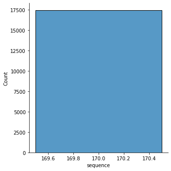

```python
sns.displot(annot_df["sequence"].str.len())
plt.show()
# plt.gca().set_yscale("log")
```

**Num and frac unique seqs at 140 cycles**

If there are 2 fragments that share the first 140 bp, the wetlab needs to know.

```python
def find_cycle(sequences, low, high):
    '''
    Find the cycle in which these sequences are distinguishable.
    This point should be < 140.
    '''

    mid = (high + low) // 2

    nunique = sequences.str.slice(0, mid).nunique()

    if low >= high:
        return mid

    elif nunique < len(sequences):
        return find_cycle(sequences, mid + 1, high)

    # Else the element can only be present in right subarray
    elif nunique == len(sequences):
        return find_cycle(sequences, low, mid - 1)
    else:
        raise

cycle = find_cycle(annot_df["sequence"], 0, len(annot_df["sequence"].iloc[0]))
print("Sequences are distinguishable at %i bp" % cycle)
verify(cycle < 140)
```

```
Sequences are distinguishable at 137 bp
PASS!
```

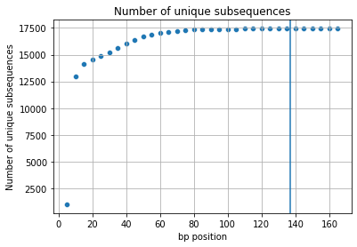

```python
x, y = [], []
for readlen in range(5, len(annot_df["sequence"].iloc[0]), 5):
    nuniq = annot_df["sequence"].str.slice(0, readlen).nunique()
    x.append(readlen)
    y.append(nuniq)
sns.scatterplot(x=x, y=y)
plt.grid()
plt.xlabel("bp position")
plt.ylabel("Number of unique subsequences")
plt.title("Number of unique subsequences")
plt.axvline(x=cycle)
plt.show()
```

## Sequence checks for 3' BC.

Sequences that contain restriction sites can't be used in 3'BC construction. Check for cut sites for restriction enzymes SbfI and EcoRI.

- CCTGCAGG (SbfI)
- GAATTC (EcoRI)

```python
count = np.sum(annot_df['sequence'].str.contains('GAATTC'))
verify(count==0)
print(count)
print("number of sequences with Sbfl cut site: ", count)
```

[output not shown]

```python
count = np.sum(annot_df['sequence'].str.contains('CCTGCAGG'))
verify(count==0)
print("number of sequences with EcoRI cut site: ", count)
```

[output not shown]

# GC content and thermodynamics

- GC content should be between 0.3 and 0.7 for most sequences
- Tm: uses seqfold library to compute the annealing temperature between seq1 and its reverse complement. Higher temperature usually means higher stability, which may cause problems during PCR.
- dG: uses RNAfold to compute the minimum free energy of a sequence. lower numbers indicate higher stability, which may cause issues.

## Some references:

- For both Inness and Santigold, dG and Tm centers around -11 and 80, respectively

```python
dG_df = pd.read_table(dG_path, header=None, names=["PB_ID", "sequence", "min_energy_struct", "dG"])
Tm_df = pd.read_table(Tm_path, header=None, names=["PB_ID", "Tm"])
```

```python
thermo_df = pd.merge(
    dG_df, Tm_df, left_on="PB_ID", right_on="PB_ID", validate="1:1"
).assign(
    seqlen=lambda x: x["sequence"].str.len(),
    gc_frac=lambda x: (x["sequence"].str.count("G") + x["sequence"].str.count("C"))
    / x["sequence"].str.len()
)
```

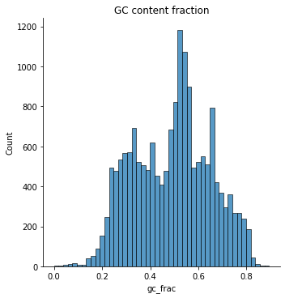

```python
sns.displot(data=thermo_df, x="gc_frac")
plt.title("GC content fraction")
plt.show()
```

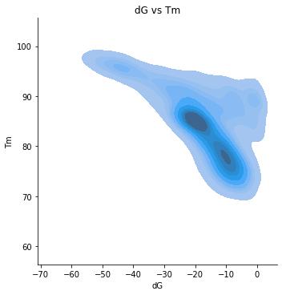

```python
sns.displot(data=thermo_df, x="dG", y="Tm", kind="kde", fill=True)
plt.title("dG vs Tm")
plt.show()
```

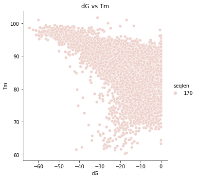

```python
sns.relplot(data=thermo_df, x="dG", y="Tm", hue="seqlen")
plt.title("dG vs Tm")
plt.show()
```

# Complexity

```python
compression_ratios = annot_df["sequence"].apply(
    lambda s: len(zlib.compress(s.encode("UTF-8"))) / len(s)
).values
```

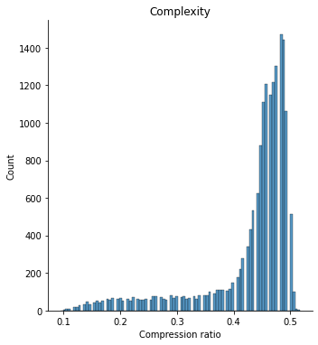

```python
sns.displot(compression_ratios, kind="hist")
plt.title("Complexity")
plt.xlabel("Compression ratio")
plt.show()
```

# Per-base pair diversity

During sequencing, we need each bp present at all positions. Otherwise, the experiment needs to be modfied (for example, use PhiX spikein).

```python
seq_matrix = np.vstack([np.array([char for char in i]) for i in list(annot_df['sequence'])])

count = 0
for i in range(seq_matrix.shape[-1]):

    if len(set(seq_matrix[:,0])) < 4:
        count += 1
        break

verify(count == 0)
del seq_matrix
```

```
PASS!
```

# k-mers

```python
ks = [2, 3, 4, 6, 8, 10, 12, 18, 24]
ks_plot = ks[:6]
```

```python
def compute_kmer_stats(kmer_data):
    """
    "coverage" counts the number of times the k-mer is observed across the whole dataset, while
    "multiplicity" counts the number of sequences that contain each k-mer.
    """
    k = kmer_data["k"]
    kmer_coverage = np.asarray(list(kmer_data["kmer_coverage"].values()))
    kmer_multiplicity = np.asarray(list(kmer_data["kmer_multiplicity"].values()))

    stats = {"k": k, "total_kmers": total_kmers(k)}
    stats["num_obs_kmers"] = len(kmer_coverage)
    stats["frac_kmers_observed"] = len(kmer_coverage) / total_kmers(k)
    stats["num_coverage1_kmers"] = (kmer_coverage == 1).sum()
    stats["num_multiplicity1_kmers"] = (kmer_multiplicity == 1).sum()
    stats["avg_kmer_coverage"] = np.mean(kmer_coverage)
    stats["avg_kmer_multiplicity"] = np.mean(kmer_multiplicity)
    stats["max_kmer_coverage"] = np.max(kmer_coverage)
    stats["max_kmer_multiplicity"] = np.max(kmer_multiplicity)
    stats["median_kmer_coverage"] = np.median(kmer_coverage)
    stats["median_kmer_multiplicity"] = np.median(kmer_multiplicity)

    return stats
```

## Global k-mer stats

- coverage: number of times a kmer is observed
- multiplicity: number of sequences a kmer is observed in

Here, we collect kmer stats for multiple values of k:

- total_kmers: number of possible kmers for this value of k
- num_obs_kmers: number of observed kmers
- frac_kmers_observed: fraction of kmers observed
- num_coverage1_kmers: number of kmers found just once
- num_multiplicity1_kmers: number of kmers found in just one sequences
- max/median/avg_kmer_coverage: max/median/average coverage across each kmer
- max/median/avg_kmer_multiplicity: max/median/average multiplicity across each kmer

Note: the k-mer matrix is switched from LIL format to CSR format.

```python
# don't print output
with io.capture_output() as captured:

    seqs = list(annot_df["sequence"])
    kmer_data = {}
    for k in tqdm(ks):
        kmer_data[k] = {
            "k": k,
            "kmer_coverage":     sequences_to_kmer_counts(k, seqs),
            "kmer_multiplicity": sequences_to_kmer_counts(k, seqs, unique=True),
            "kmer_matrix":       sequences_to_kmer_matrix(k, seqs).tocsr()
        }
```

```python
stats_df = pd.DataFrame([compute_kmer_stats(kmer_data[k]) for k in ks]).set_index("k").T
```

```python
stats_df
```

| k | 2 | 3 | 4 | 6 | 8 | 10 | 12 | 18 | 24 |
| --- | --- | --- | --- | --- | --- | --- | --- | --- | --- |
| total_kmers | 16.0000 | 64.000000 | 256.000000 | 4096.000000 | 65536.000000 | 1.048576e+06 | 1.677722e+07 | 6.871948e+10 | 2.814750e+14 |
| num_obs_kmers | 16.0000 | 64.000000 | 256.000000 | 4096.000000 | 64914.000000 | 6.186580e+05 | 1.425753e+06 | 1.874691e+06 | 1.973303e+06 |
| frac_kmers_observed | 1.0000 | 1.000000 | 1.000000 | 1.000000 | 0.990509 | 5.899982e-01 | 8.498150e-02 | 2.728034e-05 | 7.010581e-09 |
| num_coverage1_kmers | 0.0000 | 0.000000 | 0.000000 | 0.000000 | 1439.000000 | 2.452240e+05 | 1.173620e+06 | 1.769036e+06 | 1.874974e+06 |
| num_multiplicity1_kmers | 0.0000 | 0.000000 | 0.000000 | 0.000000 | 1450.000000 | 2.466280e+05 | 1.183304e+06 | 1.786302e+06 | 1.890165e+06 |
| avg_kmer_coverage | 184178.3125 | 45772.125000 | 11374.917969 | 702.418213 | 43.784561 | 4.537817e+00 | 1.944575e+00 | 1.423094e+00 | 1.298959e+00 |
| avg_kmer_multiplicity | 16201.0625 | 12506.390625 | 5952.277344 | 540.023438 | 36.249715 | 3.866791e+00 | 1.690193e+00 | 1.289575e+00 | 1.211249e+00 |
| max_kmer_coverage | 329946.0000 | 167377.000000 | 119899.000000 | 88360.000000 | 75110.000000 | 6.542500e+04 | 5.697300e+04 | 3.487900e+04 | 1.632200e+04 |
| max_kmer_multiplicity | 17365.0000 | 16193.000000 | 11882.000000 | 4847.000000 | 3973.000000 | 3.814000e+03 | 3.715000e+03 | 3.353000e+03 | 2.471000e+03 |
| median_kmer_coverage | 169140.0000 | 37770.000000 | 8695.500000 | 428.000000 | 21.000000 | 2.000000e+00 | 1.000000e+00 | 1.000000e+00 | 1.000000e+00 |
| median_kmer_multiplicity | 16390.0000 | 12917.000000 | 5891.500000 | 398.000000 | 21.000000 | 2.000000e+00 | 1.000000e+00 | 1.000000e+00 | 1.000000e+00 |

TODO: make table nicer

**TODO**: 4 columns: the hist/scatter from below; one row per value of k

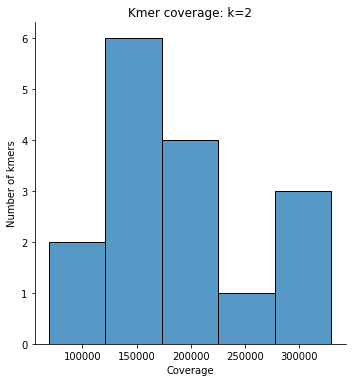

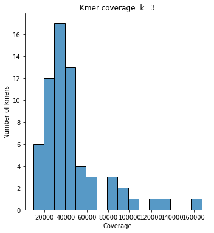

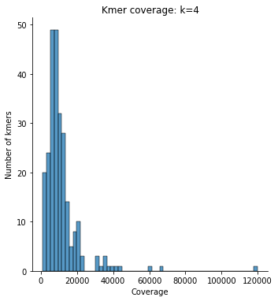

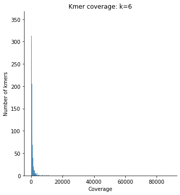

[figure not shown]

[figure not shown]

```python
for k in ks_plot:
    values = np.asarray(list(kmer_data[k]["kmer_coverage"].values()))
    sns.displot(values)
    plt.gca().set_title(f"Kmer coverage: k={k}")
    plt.gca().set_xlabel("Coverage")
    plt.gca().set_ylabel("Number of kmers")
```

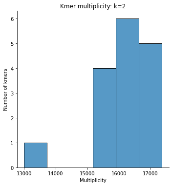

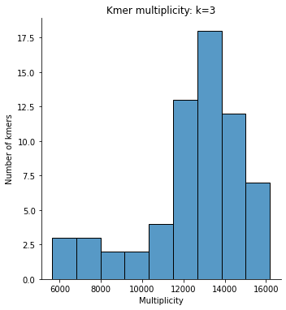

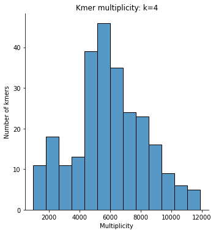

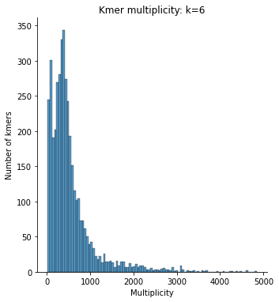

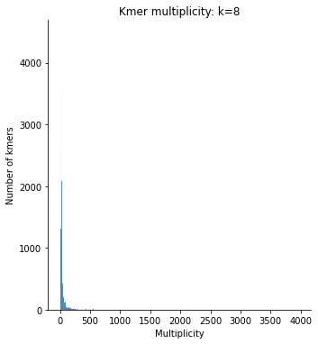

[figure not shown]

```python
for k in ks_plot:
    values = np.asarray(list(kmer_data[k]["kmer_multiplicity"].values()))
    sns.displot(values)
    plt.gca().set_title(f"Kmer multiplicity: k={k}")
    plt.gca().set_xlabel("Multiplicity")
    plt.gca().set_ylabel("Number of kmers")
```

# Coverage vs multiplicity

This can highlight motifs that are concentrated to a subset of sequences.

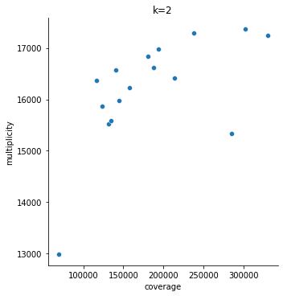

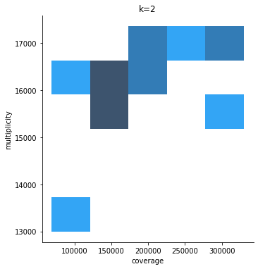

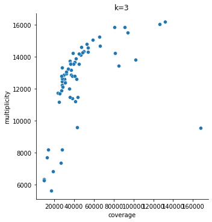

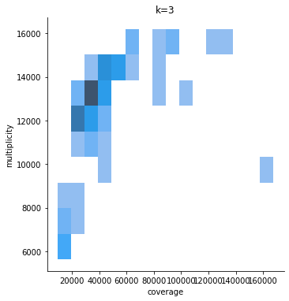

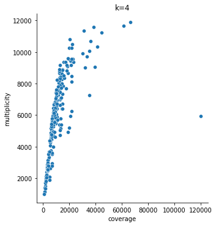

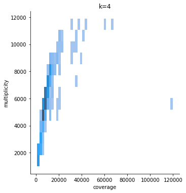

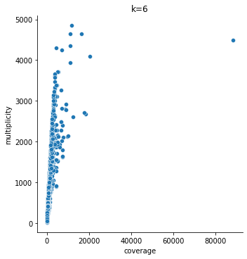

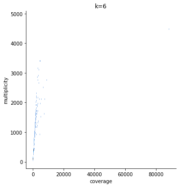

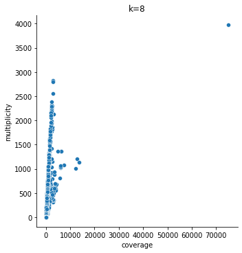

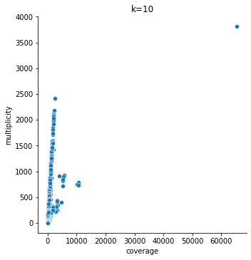

```python
for k in ks_plot:
    kmers = kmer_data[k]["kmer_coverage"].keys()
    x = [kmer_data[k]["kmer_coverage"][kmer] for kmer in kmers]
    y = [kmer_data[k]["kmer_multiplicity"][kmer] for kmer in kmers]


    sns.relplot(x=x, y=y)
    plt.gca().set_title(f"k={k}")
    plt.gca().set_xlabel(f"coverage")
    plt.gca().set_ylabel(f"multiplicity")

    if k < 8:
        # hard to read and takes a too much memory for k > 8
        sns.displot(x=x, y=y, kind="hist", rug=False)
        plt.gca().set_title(f"k={k}")
        plt.gca().set_xlabel(f"coverage")
        plt.gca().set_ylabel(f"multiplicity")

    plt.show()
    plt.clf()
    plt.close()
    gc.collect()
```

```python
from pprint import pprint
for k in ks:
    pprint(k)
    print("k-mer counts")
    pprint(kmer_data[k]["kmer_coverage"].most_common(5))
    print("seq counts")
    pprint(kmer_data[k]["kmer_multiplicity"].most_common(5))
    print()
```

```
2
k-mer counts
[('GG', 329946), ('AG', 302163), ('TT', 284740), ('GA', 237627), ('AA', 214087)]
seq counts
[('AG', 17365), ('GA', 17295), ('GG', 17252), ('CA', 16975), ('GC', 16834)]

3
k-mer counts
[('TTT', 167377),
 ('AGG', 131951),
 ('GAG', 126624),
 ('GGG', 102287),
 ('GGA', 94369)]
seq counts
[('AGG', 16193), ('GAG', 16037), ('CAG', 15878), ('AGA', 15866), ('GGA', 15521)]

4
k-mer counts
[('TTTT', 119899),
 ('GAGG', 66424),
 ('GGAG', 61445),
 ('AGGA', 44750),
 ('GCAG', 41531)]
seq counts
[('GAGG', 11882),
 ('GGAG', 11662),
 ('CAGG', 11587),
 ('GAGA', 11353),
 ('AGGA', 11245)]

6
k-mer counts
[('TTTTTT', 88360),
 ('AGGAGG', 20440),
 ('GAGGAG', 18325),
 ('GGAGGA', 17718),
 ('AGGCAG', 16503)]
seq counts
[('GGGAGG', 4847),
 ('CAGGAG', 4642),
```

[output cut: 58 more lines]

```
 ('GGTCAGGAGTTCGAGACC', 1535)]

24
k-mer counts
[('TTTTTTTTTTTTTTTTTTTTTTTT', 16322),
 ('GAGGAGGAGGAGGAGGAGGAGGAG', 5190),
 ('AGGAGGAGGAGGAGGAGGAGGAGG', 5184),
 ('GGAGGAGGAGGAGGAGGAGGAGGA', 5162),
 ('TTATTTATTTATTTATTTATTTAT', 2668)]
seq counts
[('TTTTTTTTTTTTTTTTTTTTTTTT', 2471),
 ('CTTTTTTTTTTTTTTTTTTTTTTT', 1701),
 ('TTTTTTTTTTTTTTTTTTTTTTTG', 1633),
 ('AGGTCAGGAGTTCGAGACCAGCCT', 1264),
 ('GGTCAGGAGTTCGAGACCAGCCTG', 1214)]
```